# Who funds what?

Research funding for LGU Agricultural Colleges, 2000-2020

Victoria C. Fletcher

2023-05-15

```r
##### SET THIS TO YOUR OWN PATH! #####
path_to_box <- '~/Library/CloudStorage/Box-Box/lgu'
```

# Awards Data

## Awards data frame column names and descriptions:

- uni_state: “University State”
- inventor_last: “Inventor Last Name”
- inventor_first_1: “Inventor Initial of First Name”
- breeder: “Inventor Matches With Inventor in License Data”
- Sponsor: “Award Sponsor”
- AwardAmt: “Amount of Award $”
- StartDate: “Start of Award Period”
- EndDate: “End of Award Period”
- ProjectTitle: “Title of Project”
- PIFullName: “Full Name of Principle Investigator”
- Dept: “Department”
- inventor_first: “Inventor First Name”
- start_year: “Project Starting Year”
- end_year: “Project Ending Year”
- amt: “Amount of Award”

```r
colnames(all_awards)
```

```
##  [1] "uni_state"        "inventor_last"    "inventor_first_1" "breeder"
##  [5] "Sponsor"          "AwardAmt"         "StartDate"        "EndDate"
##  [9] "ProjectTitle"     "PIFullName"       "Dept"             "inventor_first"
## [13] "start_year"       "end_year"         "amt"
```

## Renaming Column Names for Clarity:

- inventor_last –> “inventor_lastname”
- inventor_first_1 –> “inventor_first”
- breeder –> “inventorlist_check”
- inventor_first –> “inventor_firstname”

```r
colnames(all_awards)[2] = "inventor_lastname"
colnames(all_awards)[3] = "inventor_first"
colnames(all_awards)[4] = "inventorlist_check"
colnames(all_awards)[12] = "inventor_firstname"
```

## Removing Irrelevant Columns

At this point in time, some of the columns are irrelevant and thus may cause confusion when analyzing the data. Therefore, I will go ahead and remove some of these columns with the select function:

```r
# Use select to reduce the number of columns
all_awards_revised <- all_awards %>%
  select(uni_state,inventor_lastname,inventor_first,inventorlist_check,Sponsor,amt,ProjectTitle,PIFullName,Dept,start_year,inventor_firstname,end_year) %>%
  filter(amt>0)
```

[output not shown]

## Awards Data Summaries

Across all of the grants in our awards data, what is the average amount of funding a project receives?

```r
summary(all_awards_revised$amt)
```

```
##     Min.  1st Qu.   Median     Mean  3rd Qu.     Max.
##        1    15000    40000   143409   105000 36966813
```

Does this amount vary across universities? How much money has each university gotten each year?

- Average Amount per University (all time)
  - Method: group by uni_state, and then summarize by mean and remove NA values

```r
all_awards_revised %>%
    group_by(uni_state) %>%
  summarize(mean_awardamt = mean(amt, na.rm= TRUE))
```

```
## # A tibble: 6 × 2
##   uni_state  mean_awardamt
##   <chr>              <dbl>
## 1 California       140013.
## 2 Idaho             57474.
## 3 Louisiana         38916.
## 4 Michigan         279283.
## 5 Minnesota        199345.
## 6 Montana          128976.
```

- Average Amount per University per Year
  - Method: group by uni_state and start_year and summarize by mean and remove NA values

```r
all_awards_revised %>%
    group_by(uni_state,start_year) %>%
  summarize(mean_awardamt = mean(amt, na.rm= TRUE))
```

```
## # A tibble: 134 × 3
## # Groups:   uni_state [6]
##    uni_state  start_year mean_awardamt
##    <chr>           <int>         <dbl>
##  1 California       1980       332414
##  2 California       1990        48184.
##  3 California       1994       141663.
##  4 California       1995       296308.
##  5 California       1996       266472.
##  6 California       1997       203246.
##  7 California       1998        59952.
##  8 California       1999        65690.
##  9 California       2000        91572.
## 10 California       2001        96762.
## # … with 124 more rows
```

- Sum Award Amount per University (all time)
  - Method: group by uni_state, and then summarize by sum and remove NA values

```r
all_awards_revised %>%
    group_by(uni_state) %>%
  summarize(sum_awardamt = sum(amt, na.rm= TRUE))
```

```
## # A tibble: 6 × 2
##   uni_state  sum_awardamt
##   <chr>             <dbl>
## 1 California  2355990908
## 2 Idaho        323518743.
## 3 Louisiana      8250275
## 4 Michigan     692343275.
## 5 Minnesota    993933710.
## 6 Montana      471021283
```

- Sum Amount per University per Year
  - Method: group by uni_state and start_year, summarize by sum and remove NA values

```r
all_awards_revised %>%
    group_by(uni_state,start_year) %>%
  summarize(sum_awardamt = sum(amt, na.rm= TRUE))
```

```
## # A tibble: 134 × 3
## # Groups:   uni_state [6]
##    uni_state  start_year sum_awardamt
##    <chr>           <int>        <dbl>
##  1 California       1980      1994484
##  2 California       1990       385470
##  3 California       1994       708313
##  4 California       1995     38816287
##  5 California       1996     65019099
##  6 California       1997     29064144
##  7 California       1998     12949684
##  8 California       1999     26079036
##  9 California       2000     60986931
## 10 California       2001     76054597
## # … with 124 more rows
```

- Award Amount per Grant Period
  - Method: Mutate a column of difference between start and end year, award amount on a yearly basis

```r
all_awards_revised <- all_awards_revised %>%
  mutate(grant_period = (end_year-start_year)+1)

all_awards_revised <- all_awards_revised %>%
    mutate(average_annual_awd_amt = amt/grant_period)
```

```r
all_awards_revised %>%
    group_by(uni_state, average_annual_awd_amt) %>%
  summarise(mean_average_annual_awd_amt= mean(average_annual_awd_amt))
```

```
## # A tibble: 23,670 × 3
## # Groups:   uni_state [6]
##    uni_state  average_annual_awd_amt mean_average_annual_awd_amt
##    <chr>                       <dbl>                       <dbl>
##  1 California                 0.0435                      0.0435
##  2 California                 0.130                       0.130
##  3 California                 0.143                       0.143
##  4 California                 0.2                         0.2
##  5 California                 0.25                        0.25
##  6 California                 0.333                       0.333
##  7 California                 0.4                         0.4
##  8 California                 0.667                       0.667
##  9 California                 0.833                       0.833
## 10 California                 0.909                       0.909
## # … with 23,660 more rows
```

## Awards Data Visualization

### Total Sum of Award Amount per University

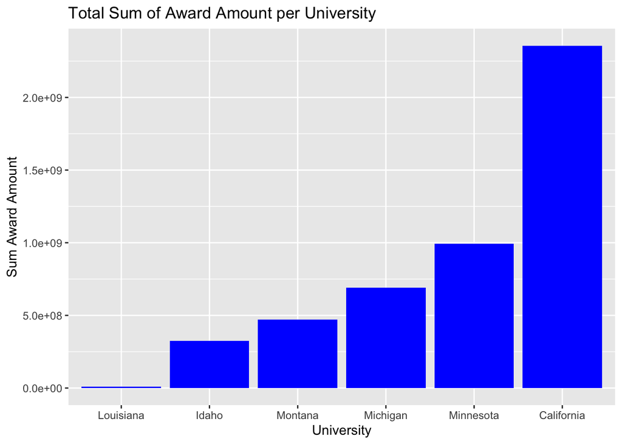

```r
library(ggplot2)
all_awards_revised %>%
    group_by(uni_state) %>%
    summarize(sum_awardamt = sum(amt)) %>%
  ggplot(mapping=aes(x=factor(uni_state, level=c('Louisiana', 'Idaho', 'Montana', 'Michigan', 'Minnesota', 'California')), y=sum_awardamt)) +
  geom_col(fill="blue") +
  labs(title= "Total Sum of Award Amount per University", x= "University", y= "Sum Award Amount")
```

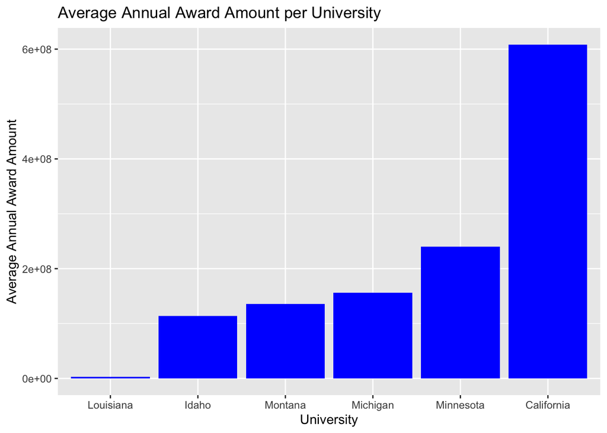

```r
library(ggplot2)
all_awards_revised %>%
    group_by(uni_state) %>%
    summarize(average_annual_awd_amt) %>%
  ggplot(mapping=aes(x=factor(uni_state, level=c('Louisiana', 'Idaho', 'Montana', 'Michigan', 'Minnesota', 'California')), y=average_annual_awd_amt)) +
  geom_col(fill="blue") +
  labs(title= "Average Annual Award Amount per University", x= "University", y= "Average Annual Award Amount")
```

### Experimenting with School Specific Award Data…

Taking a more microscopic view, we can look into the temporal awards data at the university-specific level.

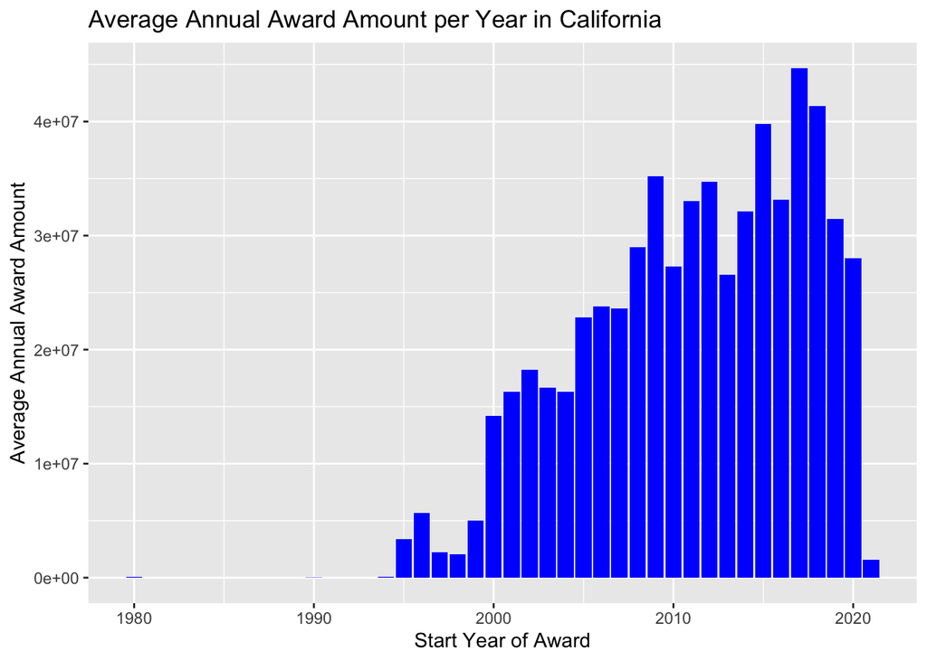

```r
all_awards_revised_ca <- all_awards_revised %>%
  filter(uni_state == "California")

library(ggplot2)
all_awards_revised_ca %>%
    group_by(uni_state,start_year) %>%
    summarize(average_annual_awd_amt) %>%
  ggplot(mapping=aes(x=start_year, y=average_annual_awd_amt)) +
  geom_col(fill="blue") +
  labs(title= "Average Annual Award Amount per Year in California", x= "Start Year of Award", y= "Average Annual Award Amount")
```

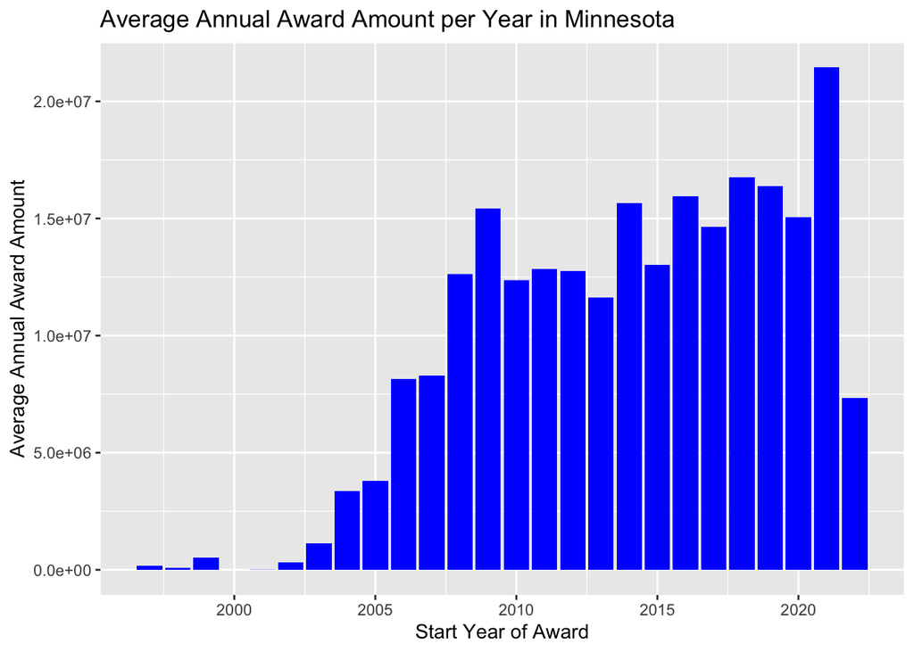

```r
all_awards_revised_mn <- all_awards_revised %>%
  filter(uni_state == "Minnesota")

library(ggplot2)
all_awards_revised_mn %>%
    group_by(uni_state,start_year) %>%
    summarize(average_annual_awd_amt) %>%
  ggplot(mapping=aes(x=start_year, y=average_annual_awd_amt)) +
  geom_col(fill="blue") +
  labs(title= "Average Annual Award Amount per Year in Minnesota", x= "Start Year of Award", y= "Average Annual Award Amount")
```

### Project Count by University

Looking at the total amount of projects undertaken by the different universities gives us a clearer understanding as to why some universities may be receiving more funding than others.

```r
all_awards_revised %>%
  group_by(uni_state) %>%
  count() %>%
  arrange(-n)
```

```
## # A tibble: 6 × 2
## # Groups:   uni_state [6]
##   uni_state      n
##   <chr>      <int>
## 1 California 16827
## 2 Idaho       5629
## 3 Minnesota   4986
## 4 Montana     3652
## 5 Michigan    2479
## 6 Louisiana    212
```

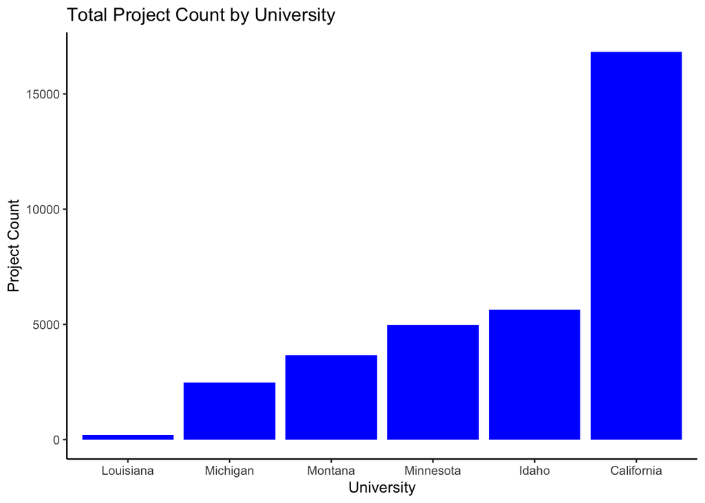

```r
ggplot(all_awards_revised, aes(x=factor(uni_state, level=c('Louisiana', 'Michigan', 'Montana', 'Minnesota', 'Idaho', 'California'))), fill = uni_state) +
  geom_bar(fill="blue") +
  theme(axis.text.x = element_text(angle=70, vjust=0.5)) +
  scale_fill_viridis_d(option = "C") +
  labs(title = "Total Project Count by University",
       x = "University", y = "Project Count", fill = "University") +
  theme_classic()
```

### Awards From a Temporal View

Grouping projects into 5 year time periods, we can depict the distribution of the amount of projects taking place at the different universities over time. In this graph, time periods begin in 2001 and end in 2020, licenses before 2001 are group as “Older” as they were deemed inconsistent in nature.

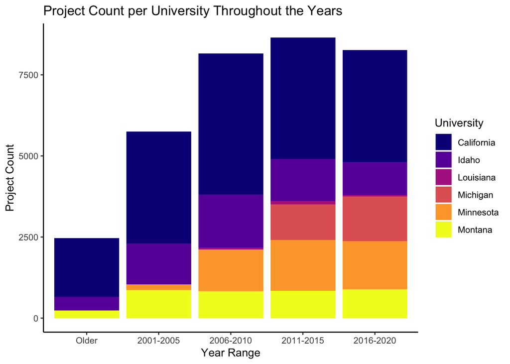

```r
all_awards_revised <- all_awards_revised %>%
  filter(start_year < 2021) %>%
  mutate(year_range = case_when(start_year > 2015 ~ "2016-2020", start_year > 2010 ~ "2011-2015", start_year > 2005 ~ "2006-2010", start_year > 2000 ~ "2001-2005", TRUE ~ "Older"))


ggplot(all_awards_revised, aes(x = factor(year_range, level=c('Older', '1996-2000', '2001-2005', '2006-2010', '2011-2015', '2016-2020')), fill = uni_state)) +
  geom_bar() +
  theme(axis.text.x = element_text(angle=70, vjust=0.5)) +
  scale_fill_viridis_d(option = "C") +
  labs(title = "Project Count per University Throughout the Years",
       x = "Year Range", y = "Project Count", fill = "University") +
  theme_classic()
```

## More Awards Data Manipulation

- Within UC Davis, how does funding vary across department? Is the data clean?
  - UC Davis Exploration: Looking at mean award amounts across all the different departments at UC Davis it becomes apparent that this data is not very clean. There are repetitions in programs such as: “International Ag Program” and “International Ag Programs”. Other departments such as “Phoenix” or “Metro Cluster” that are not clearly understood where these categories could fall into. As we do not have a clear understanding as to what these departments are/mean and how they should be categorized we will most likely avoid grouping by departments and cleaning this data.

```r
all_awards_revised %>%
  filter(uni_state == "California") %>%
  group_by(Dept) %>%
  summarize(mean_awardamt = mean(amt))
```

```
## # A tibble: 41 × 2
##    Dept                           mean_awardamt
##    <chr>                                  <dbl>
##  1 Ag & Resource Economics              169292.
##  2 Ag:Biological & Ag Engineering        10000
##  3 Agr & Env Sci Deans Office           270838.
##  4 Agronomy & Range Science             101223.
##  5 Animal Science                       130391.
##  6 Aquaculture & Fisheries Prog            200
##  7 Avian Sciences                        10512.
##  8 Bftv Admin                           133637
##  9 Biological & Ag Engineering          198065.
## 10 CAES International Programs          115847
## # … with 31 more rows
```

# Inventors Data

## Describe the inventors data

## Inventors data frame column names and descriptions:

- uni_state: “University State”
- inventor_last: “Inventor Last Name”
- inventor_first: “Inventor First Name”
- inventor_first_1: “Inventor First Name Initial”
- inventor_ID: “Inventor ID”

```r
colnames(inventors)
```

```
## [1] "uni_state"        "inventor_last"    "inventor_first"   "inventor_first_1"
## [5] "inventor_ID"
```

## Inventors Data Summary

- Inventors per state
  - Method: look into inventors data frame, group by university state and summarize through summing the inventor IDs per university.

```r
inventors %>%
  group_by(uni_state) %>%
  summarize(sum_inventor_state = sum(inventor_ID))
```

```
## # A tibble: 13 × 2
##    uni_state   sum_inventor_state
##    <chr>                    <int>
##  1 Arizona                      1
##  2 California                 560
##  3 Idaho                      385
##  4 Kansas                     594
##  5 Louisiana                 2376
##  6 Michigan                  2987
##  7 Minnesota                 6958
##  8 Mississippi               2070
##  9 Montana                   2214
## 10 Oklahoma                  3176
## 11 Oregon                    2989
## 12 Washington                6815
## 13 Wyoming                    501
```

- Number of *unique* inventors in our inventors data frame
  - Method: In order to double check that there are/are not duplicates of inventors in our data frame we will go ahead and take the number of distinct inventors through taking the number of distinct IDs and comparing that to the number of distinct inventor first name, last name, and first initial.
    - Discovery: There are duplicate inventors in the data frame! These are inventors who are registered inventors in multiple states, these include: William D Stegmeir (Michigan, Kansas, Oregon, Minnesota) and Chaofu Lu (Montana and Washington)

```r
#unique(inventors$inventor_ID)
n_distinct(inventors$inventor_ID)
```

```
## [1] 251
```

```r
n_distinct(inventors$inventor_last,inventors$inventor_first, inventors$inventor_first_1)
```

```
## [1] 247
```

```r
#duplicated(select(inventors,inventor_last,inventor_first,inventor_first_1))
##why are these numbers different, is inventor_ID not unique to each individual inventor or just a general count of how many inventors we have? How can I double check my work
#Duplicates of William D Stegmeir (Michigan, Kansas, Oregon, Minnesota) and Chaofu Lu (Montana and Washington)

##JOIN--> visualization and summary (finish in next couple of days), aiming to join awards data and inventor data.
  #-
```

- Comparing this number of *unique* inventors in our inventors data frame to our *unique* inventors (PIs) in our awards data frame.
  - There is a large discrepancy between the number of *unique* inventors between the two data frames
    - Inventor df: 247
    - Awards df: 3197

```r
#unique(all_awards$PIFullName)
n_distinct((all_awards$PIFullName))
```

```
## [1] 3197
```

```r
#all_awards_revised %>%
 # filter(breeder==T)

n_distinct(all_awards$inventor_ID)
```

```
## [1] 0
```

## Questions to continue working on:

- Of the award data that we have for breeder inventors (so keep using your filtered breeder == T data frame), what departments are the breeders coming from? How many breeders are in each department?
- Again considering only the breeder award data, how much money has each university’s breeders gotten each year? (Hint: again, group_by uni_state and year again with this data frame)
- Who are the top funders of awards to breeders? (i.e. who is giving out the most money?

# Joining

## Renaming Column Names for Clarity:

```r
colnames(inventors)
```

```
## [1] "uni_state"        "inventor_last"    "inventor_first"   "inventor_first_1"
## [5] "inventor_ID"
```

```r
colnames(inventors)[2] = "inventor_lastname"
colnames(inventors)[3] = "inventor_first"
colnames(inventors)[4] = "inventor_first_initial"
colnames(inventors)[5] = "inventor_firstname"
```

```r
#awards_inventors_joined <- left_join(inventors, all_awards_revised, by="inventor_firstname")

#how do I join by more than one field?
```